# HW1-ICA - Minh Nguyen #2069407

```python
import cv2
from matplotlib import pyplot as plt
```

### Task a:

- Load an image using OpenCV convert it from BGR to an RGB color format
- Display the image using matplotlib

```python
img = cv2.imread("cat_on_sofa.png")
```

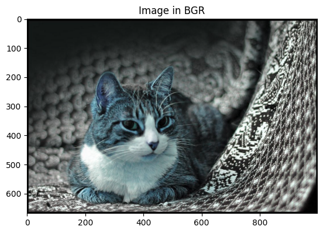

```python
# display the image with matplotlib
plt.imshow(img)
plt.title("Image in BGR")
```

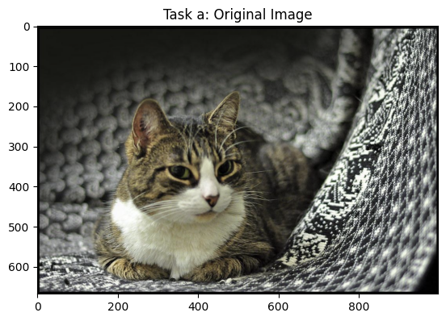

```python
# convert from BGR to RGB
img_rgb = cv2.cvtColor(img, cv2.COLOR_BGR2RGB)
# display the image with matplotlib
plt.imshow(img_rgb)
plt.title("Task a: Original Image")
```

### Task b:

- Print (i) the number of pixels and (ii) the height, width, and number of channels of the

loaded image.

```python
print("Task b:")
print("- Number of pixels: ", str(img.size))
print("- Shape/Dimensions: " + str(img.shape))
print("- Image height: ", str(img.shape[0]))
print("- Image width: ", str(img.shape[1]))
print("- Number of channels: ", str(img.shape[2]))
```

[output not shown]

### Task c:

- Isolate the information of the Red, Green, and Blue channels of the image and plot them

in the Jupyter Notebook using Matplotlib

```python
# split the image into 3 channels
red, green, blue = cv2.split(img_rgb)
```

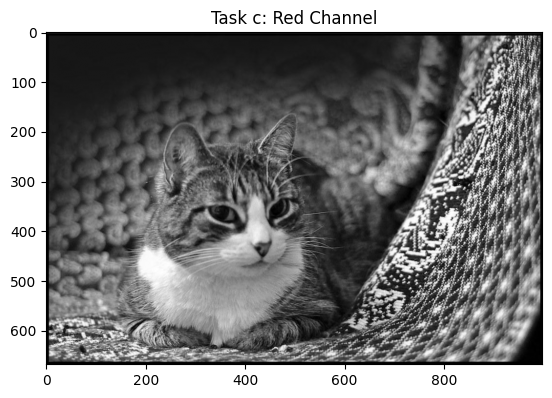

```python
plt.imshow(red, cmap='gray')
plt.title('Task c: Red Channel')
```

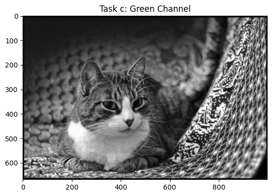

```python
plt.imshow(green, cmap='gray')
plt.title('Task c: Green Channel')
```

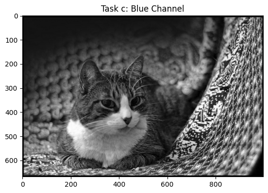

```python
plt.imshow(blue, cmap='gray')
plt.title('Task c: Blue Channel')
```

### Task d:

- Calculate the unnormalized histograms of the Red, Green, and Blue channels of the

image and plot them using Matplotlib

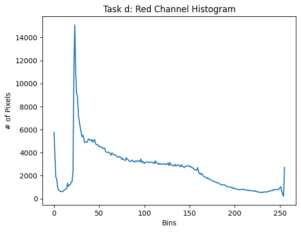

```python
# calculate the histogram of the red channel
red_hist = cv2.calcHist([red], [0], None, [256], [0, 256])
plt.plot(red_hist)
plt.xlabel('Bins')
plt.ylabel('# of Pixels')
plt.title('Task d: Red Channel Histogram')
```

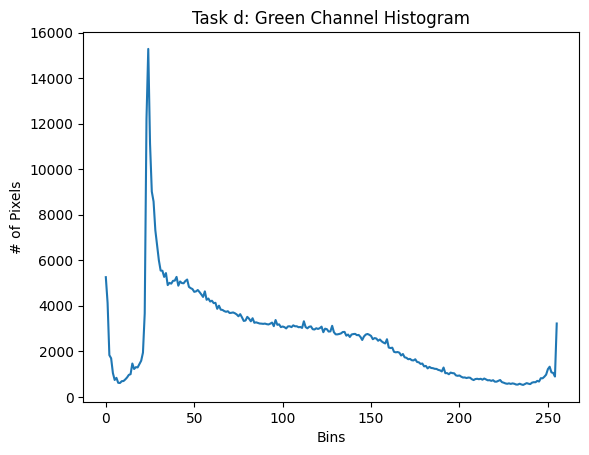

```python
# calculate the histogram of the green channel
green_hist = cv2.calcHist([green], [0], None, [256], [0, 256])
plt.plot(green_hist)
plt.xlabel('Bins')
plt.ylabel('# of Pixels')
plt.title('Task d: Green Channel Histogram')
```

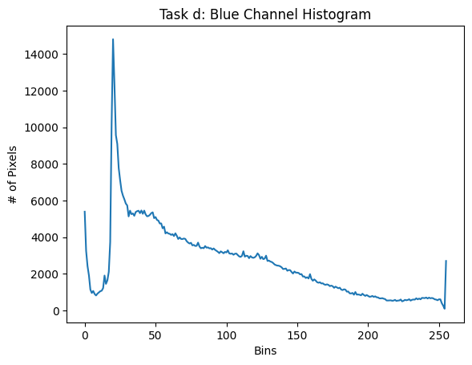

```python
# calculate the histogram of the blue channel
blue_hist = cv2.calcHist([blue], [0], None, [256], [0, 256])
plt.plot(blue_hist)
plt.xlabel('Bins')
plt.ylabel('# of Pixels')
plt.title('Task d: Blue Channel Histogram')
```

### Task e:

- Convert the image to grayscale and plot it in the Jupyter Notebook using Matplotlib

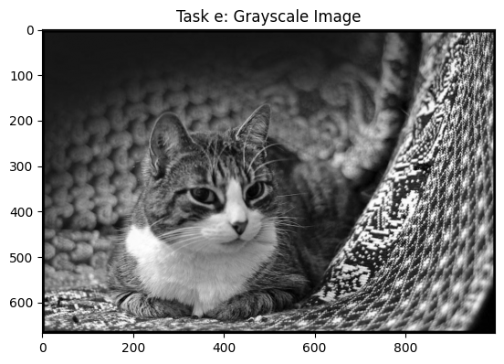

```python
# convert the image to grayscale
img_gray = cv2.cvtColor(img, cv2.COLOR_BGR2GRAY)
plt.imshow(img_gray, cmap='gray')
plt.title("Task e: Grayscale Image")
```

### Task f:

- Print (i) the number of pixels and (ii) the height, width, and number of channels of the

grayscale image

```python
print("Task f:")
print("- Number of pixels: ", str(img_gray.size))
print("- Shape/Dimensions: " + str(img_gray.shape))
print("- Image height: ", str(img_gray.shape[0]))
print("- Image width: ", str(img_gray.shape[1]))
```

```
Task f:
- Number of pixels:  666664
- Shape/Dimensions: (668, 998)
- Image height:  668
- Image width:  998
```

### Task g:

- Calculate the unnormalized histogram of the grayscale image and plot it using Matplotlib

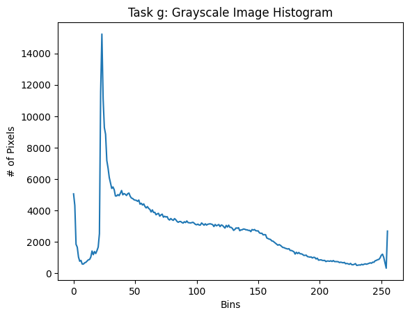

```python
gray_hist = cv2.calcHist([img_gray], [0], None, [256], [0, 256])
plt.plot(gray_hist)
plt.xlabel('Bins')
plt.ylabel('# of Pixels')
plt.title('Task g: Grayscale Image Histogram')
```

### Task h:

- Use a binary threshold on your grayscale image and plot the result in the Jupyter

Notebook using Matplotlib

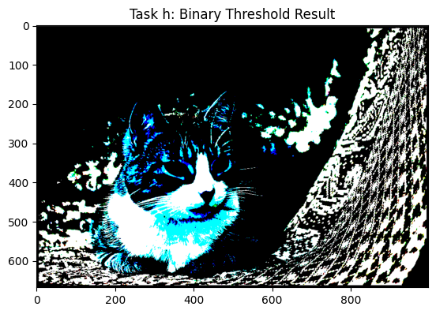

```python
# use a binary threshold with a threshold value of 128
r, threshold = cv2.threshold(img, 128, 255, cv2.THRESH_BINARY)
plt.imshow(threshold)
plt.title("Task h: Binary Threshold Result")
```

### Task i:

- Calculate the unnormalized histogram of the thresholded image and plot it using

Matplotlib

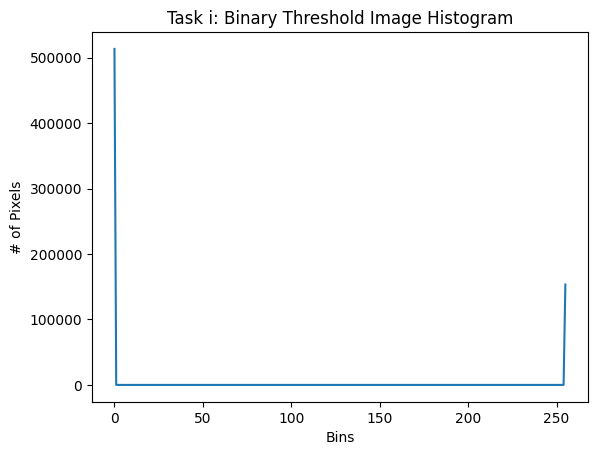

```python
# calculate the histogram of the binary threshold image
threshold_hist = cv2.calcHist([threshold], [0], None, [256], [0, 256])
plt.plot(threshold_hist)
plt.xlabel('Bins')
plt.ylabel('# of Pixels')
plt.title('Task i: Binary Threshold Image Histogram')
```

### Task j: Commentary Section

i) What are the differences you observe in the histograms for the different color channels?

ii) Converting an image to grayscale is the same operation as isolating a color channel? Yes/No and why?

- No, because the grayscale image is a single channel image, while isolating a color channel

extracts the values of a specific color (red, green or blue) from a multi-channel image.

iii) What are the differences you observe in the histograms for the grayscale image and the thresholded image?